# Light Curve of Betelgeuse

Matt Brauer

12/31/2019

## Is Betegeuse about to supernova?

`#Betelgeuse` is trending this week because of the observation that it seems to be reaching historic lows in magnitude. Victor C. (`@chmn_victor`) made this case very nicely in a twitter thread that drew data from AAVSO:

```
Today, I saw that a lot of astronomers/astrophysicists were talking about #Betelgeuse . Indeed, according to many, Betelgeuse luminosity seems to be quite low. Some say it’s extraordinary, others say it happens quite often, but all (secretly or not) hope for a supernova. 1/7

Even if I don’t believe it is likely that a supernova will happen in the next weeks, I wanted to know if this dimming was actually extraordinary. I looked at the AAVSO data, like everyone. At first, I saw what I already saw on Twitter (see figure): it seemed like it already 2/7

happened 5 times during the last 50 years. But I dug a little deeper, and I saw that in November 1985, when the luminosity was very low, a group of astronomers (Rodrigues A., Paulo) had made many measurements. ALL were very low in brightness (most around 1.8), and quite far 3/7

from other astronomers’ measurements. And I thought that I had to exclude this group of astronomers from the data, but also the others which had that kind of results. So I looked at every astronomer, and I calculated their average magnitude measured. Then, I compared it to 4/7

the overall magnitude average (during the same period of time). And I excluded all astronomers who had average magnitudes further than 0.3 from the overall average. I also excluded the average data points made from less than 10 data. Indeed, an average is supposed to smooth 5/7

measurements errors, but if we average only 1 data, and that it is wrong, the average will also be very wrong. And I got this curve (see figure). Here, it is a lot clearer that what is happening this week has never happened in the past 50 years. It might not be a sign of an 6/7

incoming supernova, but it remains exceptional, fascinating, as space always is. Thanks for reading me! (if I find some other interesting stuff about Betelgeuse, I’ll tweet it)
```

I’d like to explore these data to see if the result (that the current brightness of Betelgeuse is at an historic low) depends on the removal of specific “outlier” observers and the application of arbitrary thresholds.

First we load the data in files obtained by AAVSO. Note that these were downloaded without regard to overlaps, so `load_files` removes duplicates (and additional data files can be easily added). We also adjust for simultaneous observations and calculate the average daily magnitude in the `visible` band. Finally, we create time series objects for `visible` and `V` bands, for the union of these, and for the average daily visible magnitude observations.

```
## No encoding supplied: defaulting to UTF-8.
```

## Useful views

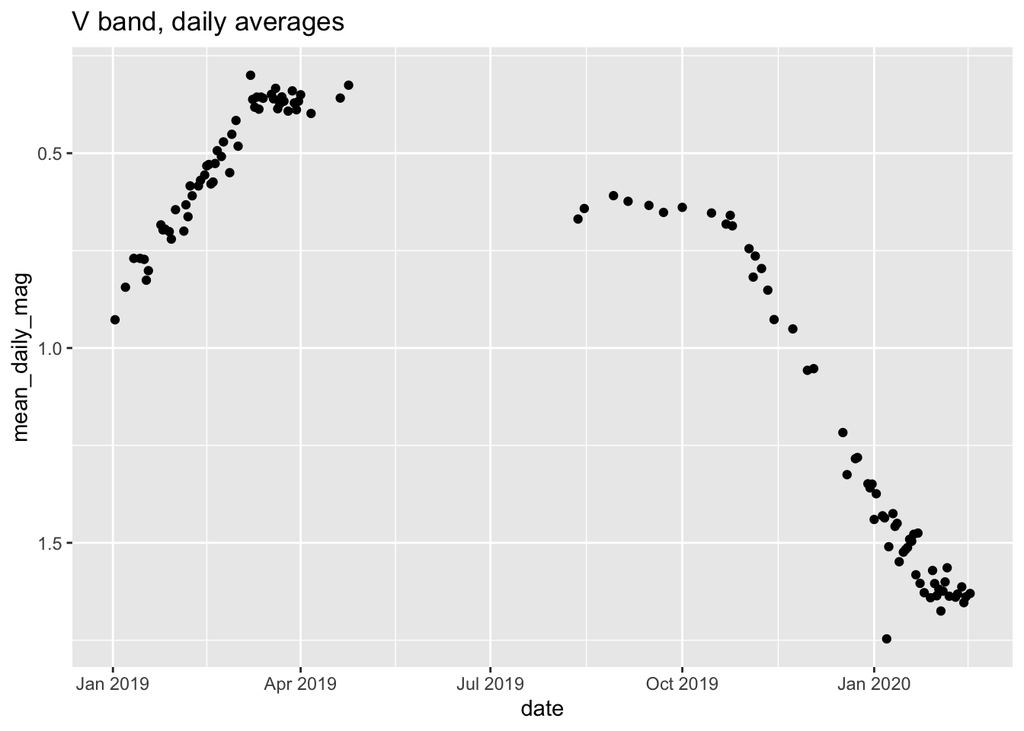

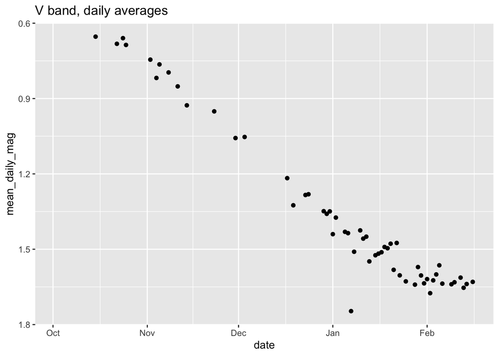

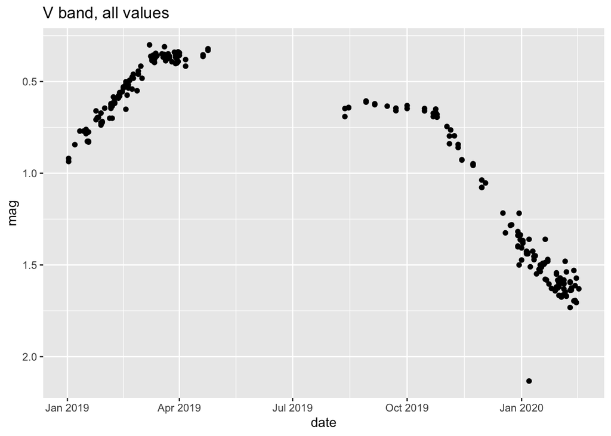

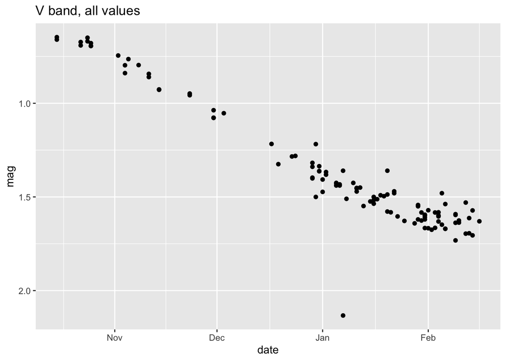

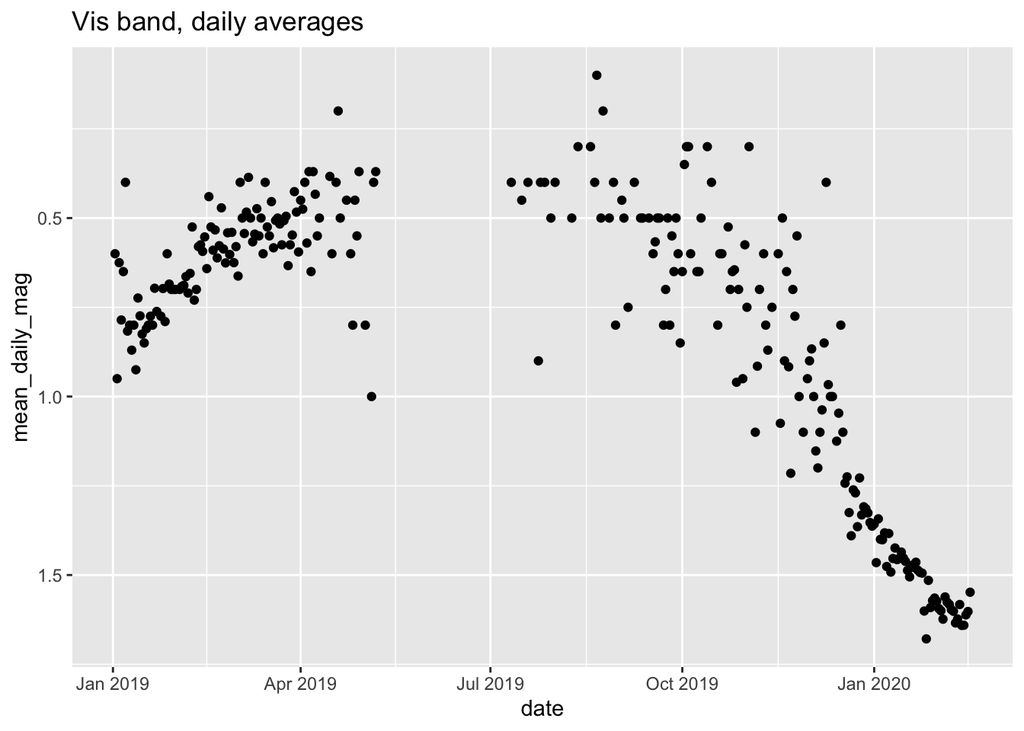

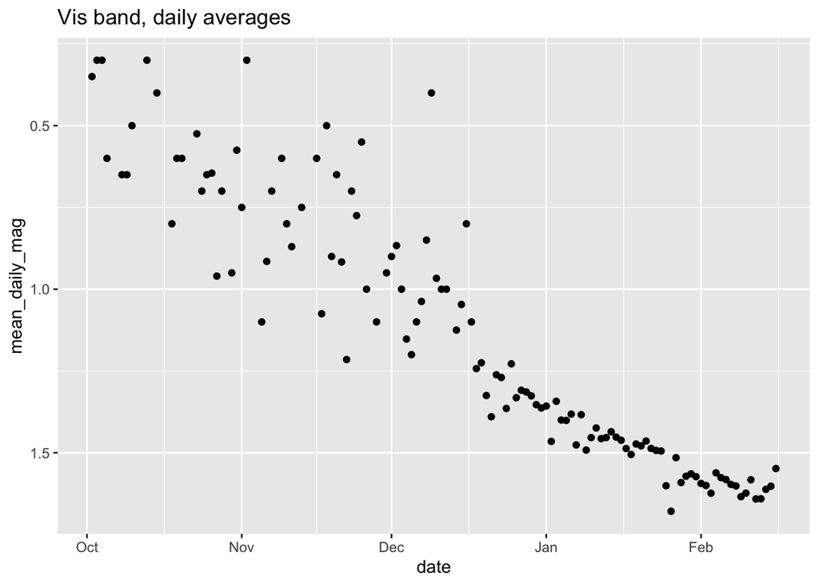

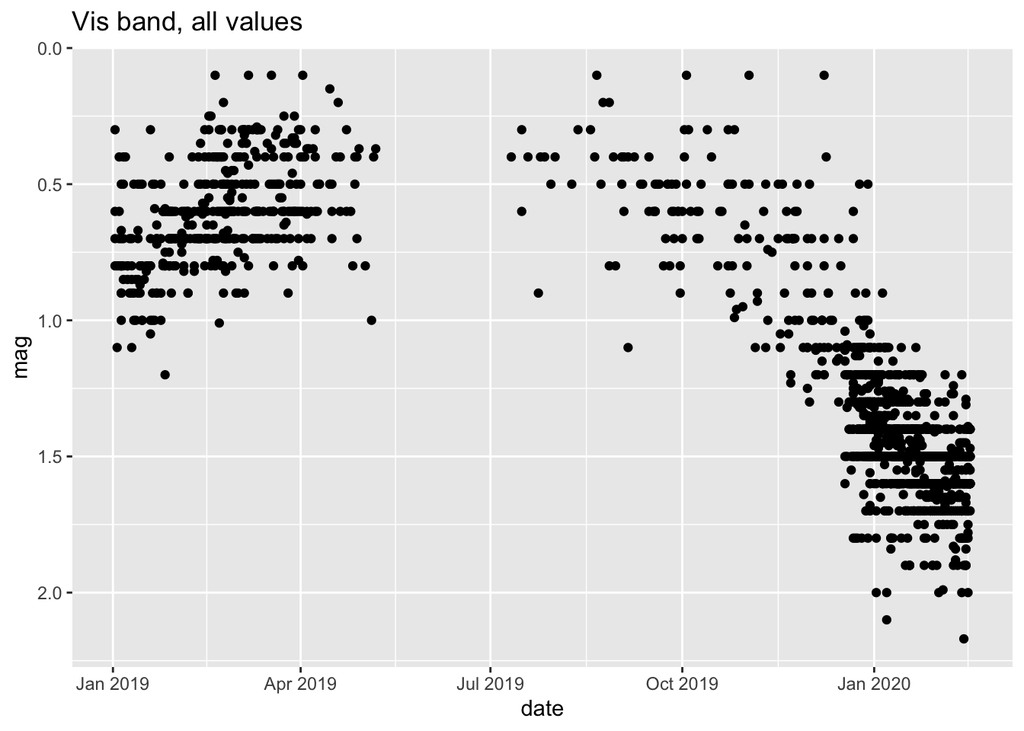

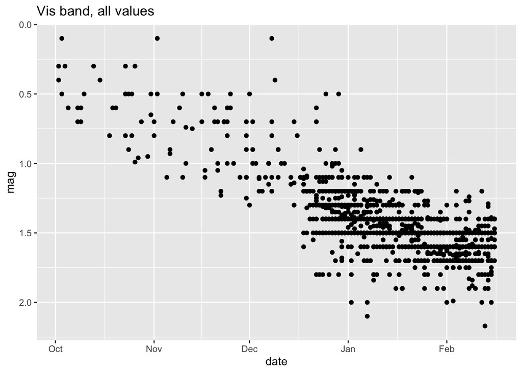

## Plotting brigtness data from AAVSO

A quick look at all of the data:

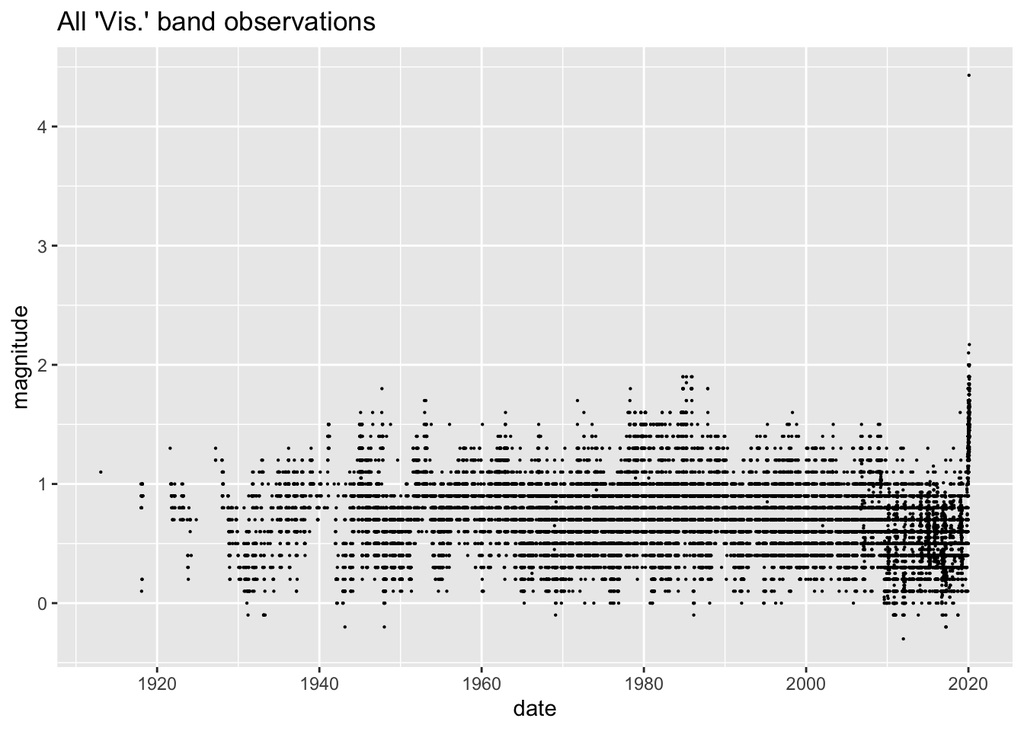

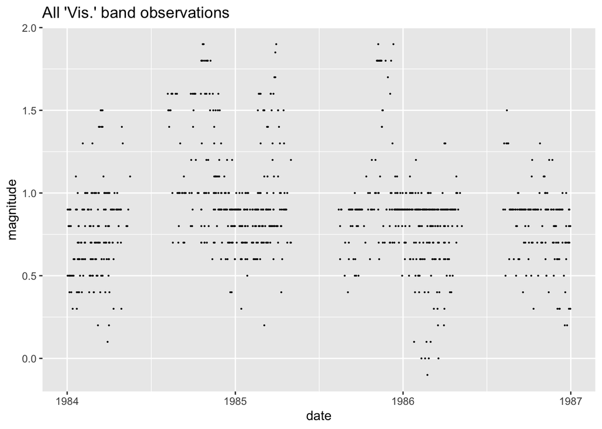

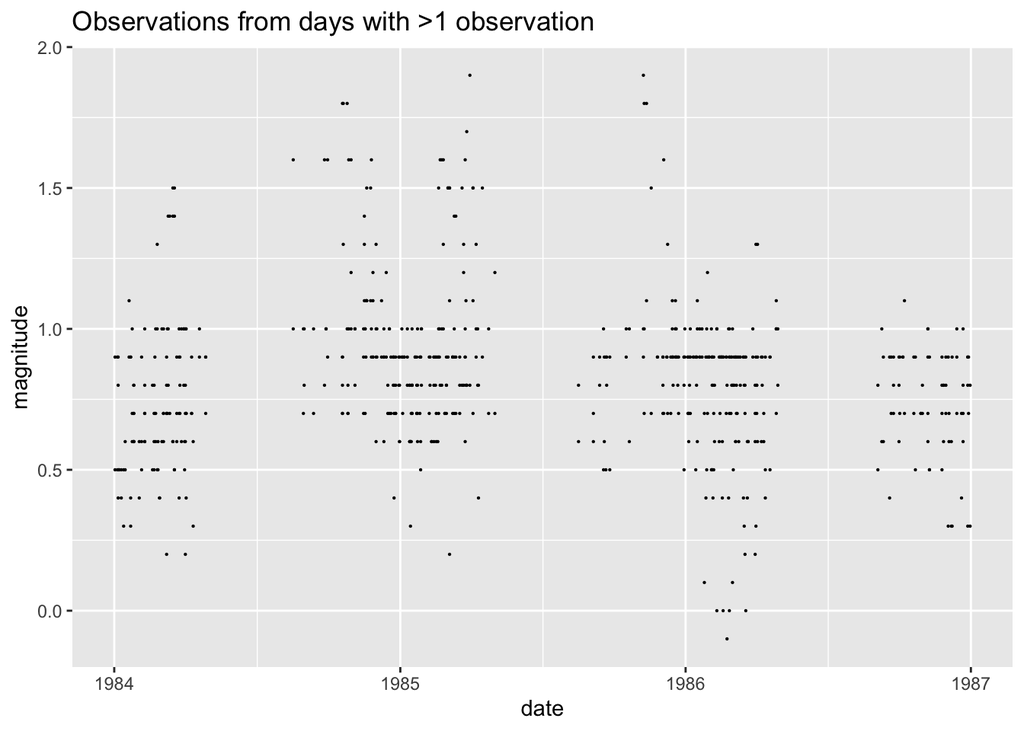

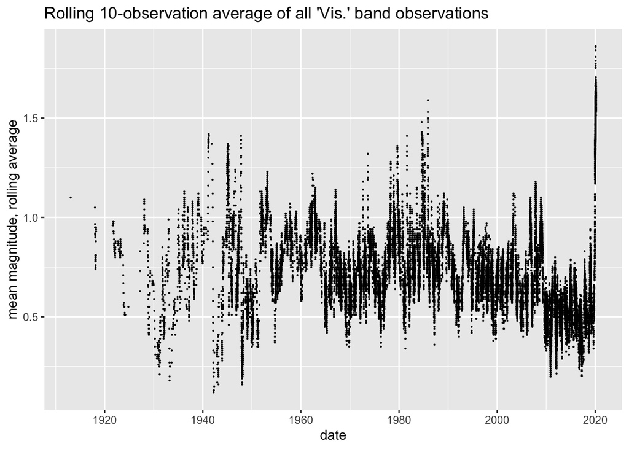

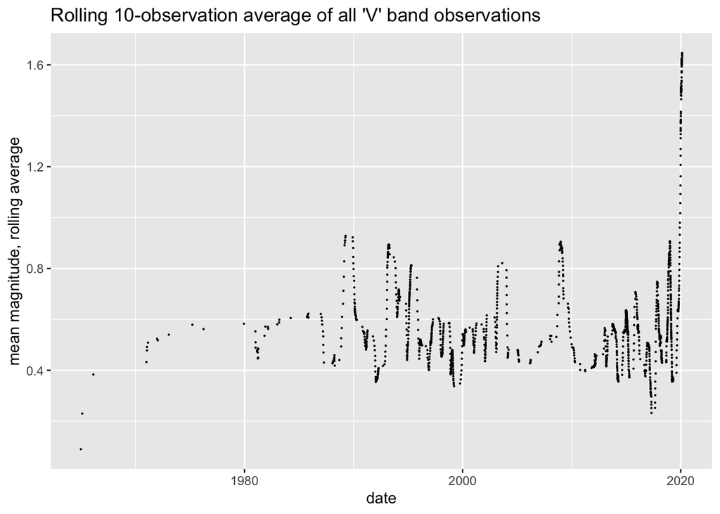

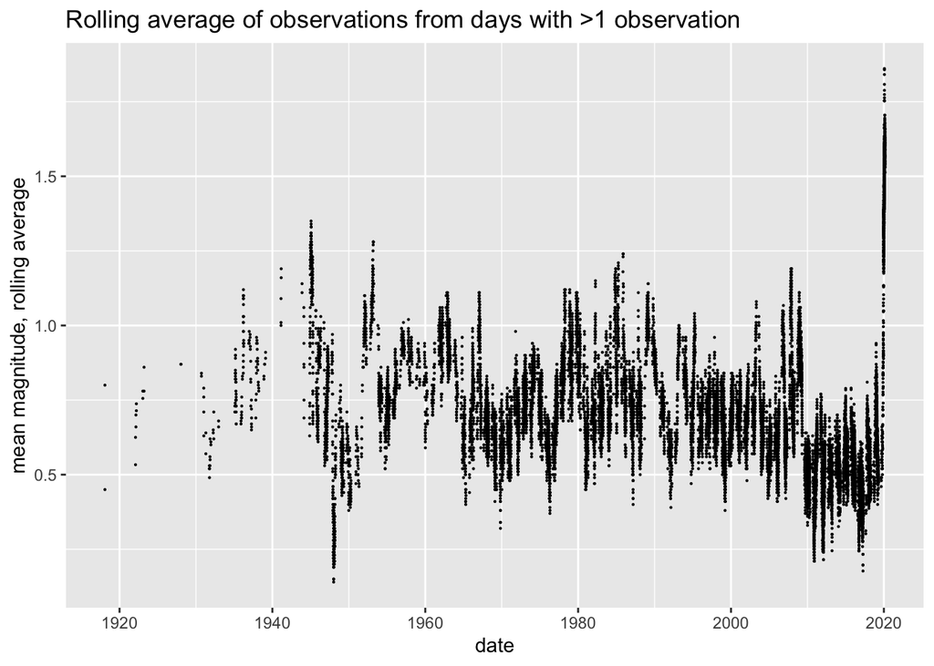

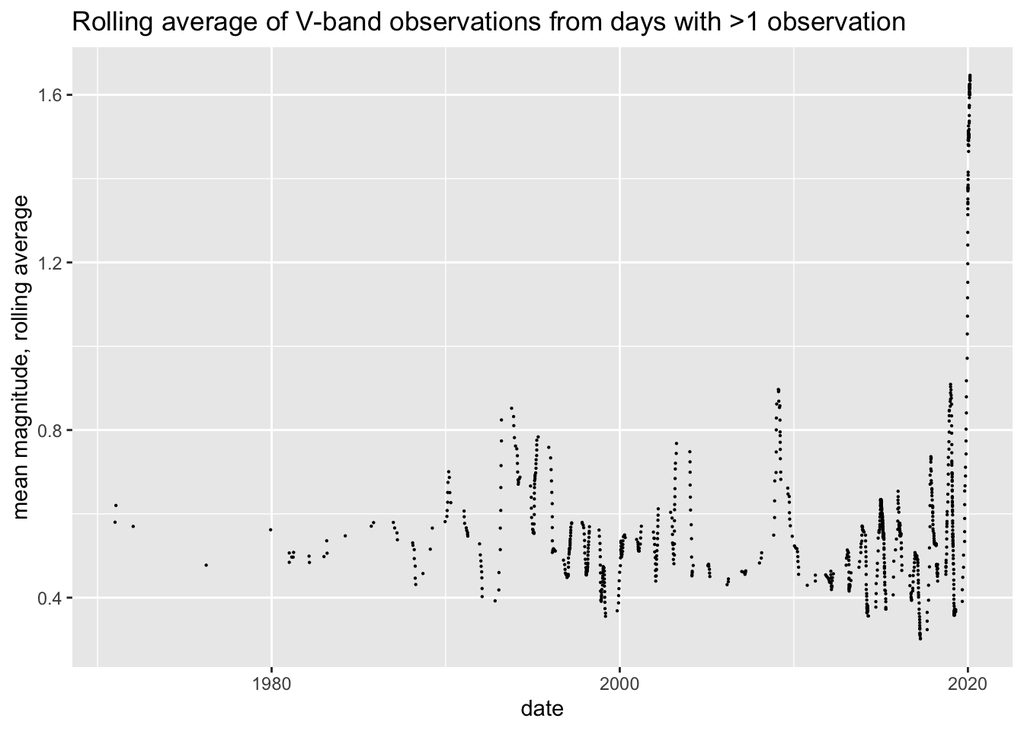

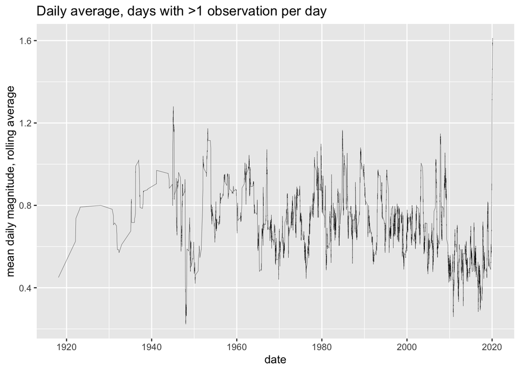

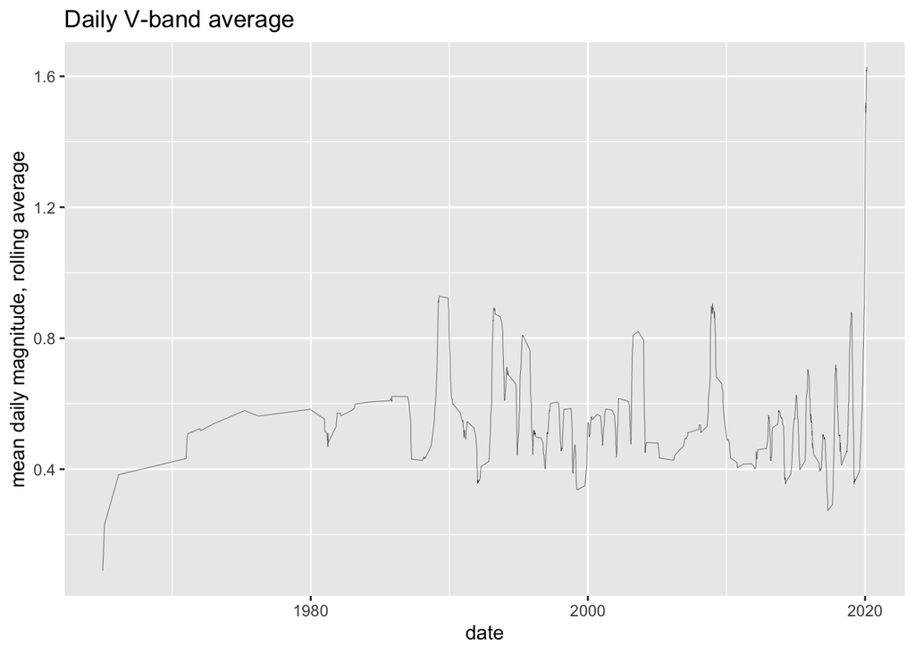

Victor C. sensibly limited the observation period to post-1965, and that seems reasonable. I’ll push it to 1945 though, to get a bigger historical sampling.

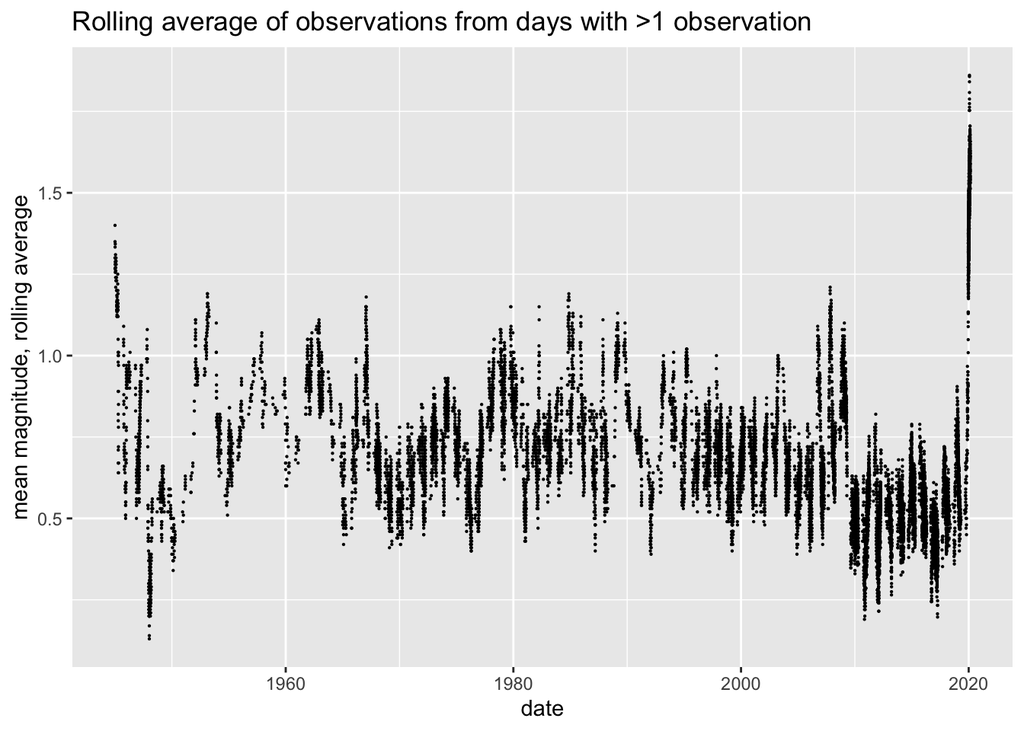

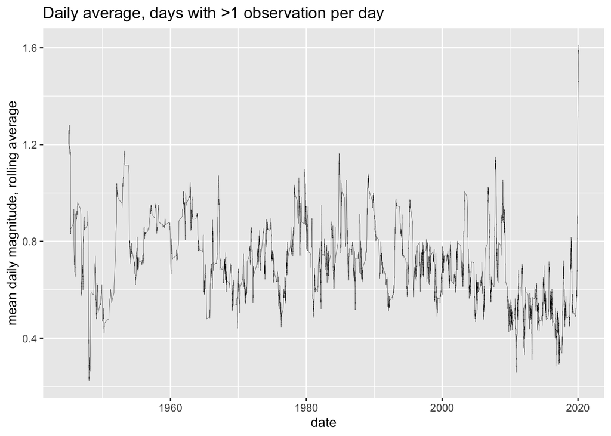

## Is “RB” more than one observer?

The user “RB” is by far the most prolific contributor to the dataset, having logged 2659 observations. However, despite the assumption that could be made that RB is a pro at variable star observation, some problems with the data from RB have emerged.

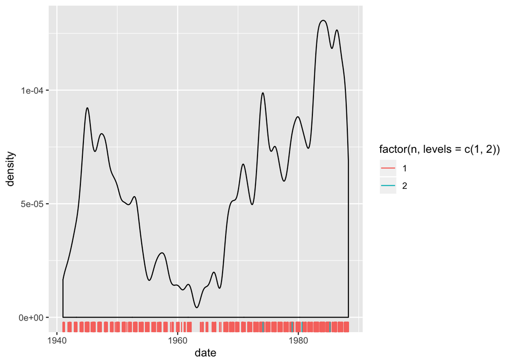